##### Question:

[output not shown]

#### Imorting Relevant libraries for analysing data and reading data into data frame.

```python
import pandas as pd
import csv
import matplotlib.pyplot as plt
%matplotlib inline
```

```python
data = pd.read_csv("D:/Udacity/ud120-projects-master/tools/titanic-data.csv")
data.head()
```

|  | PassengerId | Survived | Pclass | Name | Sex | Age | SibSp | Parch | Ticket | Fare | Cabin | Embarked |
| --- | --- | --- | --- | --- | --- | --- | --- | --- | --- | --- | --- | --- |
| 0 | 1 | 0 | 3 | Braund, Mr. Owen Harris | male | 22.0 | 1 | 0 | A/5 21171 | 7.2500 | NaN | S |
| 1 | 2 | 1 | 1 | Cumings, Mrs. John Bradley (Florence Briggs Th... | female | 38.0 | 1 | 0 | PC 17599 | 71.2833 | C85 | C |
| 2 | 3 | 1 | 3 | Heikkinen, Miss. Laina | female | 26.0 | 0 | 0 | STON/O2. 3101282 | 7.9250 | NaN | S |
| 3 | 4 | 1 | 1 | Futrelle, Mrs. Jacques Heath (Lily May Peel) | female | 35.0 | 1 | 0 | 113803 | 53.1000 | C123 | S |
| 4 | 5 | 0 | 3 | Allen, Mr. William Henry | male | 35.0 | 0 | 0 | 373450 | 8.0500 | NaN | S |

```python
data.shape
```

```
(891, 12)
```

## DATA WRANGLING

#### Checking the number of NA values in the data

```python
for col in data:
    x = sum(pd.isnull(data[col]))
    print x
```

```
0
0
0
0
0
177
0
0
0
0
687
2
```

#### There are around 177, 687 and 2 missing values in age, cabin and embarked columns. In next step we will deal with NA values by checking if we can impute or delete NA values.

```python
data[pd.isnull(data.Age)].head()
```

|  | PassengerId | Survived | Pclass | Name | Sex | Age | SibSp | Parch | Ticket | Fare | Cabin | Embarked |
| --- | --- | --- | --- | --- | --- | --- | --- | --- | --- | --- | --- | --- |
| 5 | 6 | 0 | 3 | Moran, Mr. James | male | NaN | 0 | 0 | 330877 | 8.4583 | NaN | Q |
| 17 | 18 | 1 | 2 | Williams, Mr. Charles Eugene | male | NaN | 0 | 0 | 244373 | 13.0000 | NaN | S |
| 19 | 20 | 1 | 3 | Masselmani, Mrs. Fatima | female | NaN | 0 | 0 | 2649 | 7.2250 | NaN | C |
| 26 | 27 | 0 | 3 | Emir, Mr. Farred Chehab | male | NaN | 0 | 0 | 2631 | 7.2250 | NaN | C |
| 28 | 29 | 1 | 3 | O'Dwyer, Miss. Ellen "Nellie" | female | NaN | 0 | 0 | 330959 | 7.8792 | NaN | Q |

#### After checking the data we have found that we can impute some values of NA, for age by checking if the name contains master or miss. In this we assume that for miss and master they have not come with some other children so children count will be zero and as they have miss or master, spouse count will also be zero. So either they might have come with their parents or siblings. But before assiging age brackets we need to check the distribution of age so that we can assign correct age groups brackets for NA values. First of all taking prfix out from name coloumn in data.

```python
data ["prefix"] = data["Name"].str.split(" ").str.get(1)
data
```

[output not shown]

891 rows × 13 columns

#### Now as we have taken the prefix out, now we will group ages and give them labels as kid , adult1 adult2 and senior and create a new variable "grpage" and will check what is the range of age for category Master prefix. ,and assign relevant agegrp lable to missing value for Master. Same we will do it for Ms.

```python
data["agegrp"] = pd.cut(data["Age"], [0,12,30,60,90], labels = ["Kid", "Adult1", "Adult2", "Senior"])
data.head()
```

|  | PassengerId | Survived | Pclass | Name | Sex | Age | SibSp | Parch | Ticket | Fare | Cabin | Embarked | prefix | agegrp |
| --- | --- | --- | --- | --- | --- | --- | --- | --- | --- | --- | --- | --- | --- | --- |
| 0 | 1 | 0 | 3 | Braund, Mr. Owen Harris | male | 22.0 | 1 | 0 | A/5 21171 | 7.2500 | NaN | S | Mr. | Adult1 |
| 1 | 2 | 1 | 1 | Cumings, Mrs. John Bradley (Florence Briggs Th... | female | 38.0 | 1 | 0 | PC 17599 | 71.2833 | C85 | C | Mrs. | Adult2 |
| 2 | 3 | 1 | 3 | Heikkinen, Miss. Laina | female | 26.0 | 0 | 0 | STON/O2. 3101282 | 7.9250 | NaN | S | Miss. | Adult1 |
| 3 | 4 | 1 | 1 | Futrelle, Mrs. Jacques Heath (Lily May Peel) | female | 35.0 | 1 | 0 | 113803 | 53.1000 | C123 | S | Mrs. | Adult2 |
| 4 | 5 | 0 | 3 | Allen, Mr. William Henry | male | 35.0 | 0 | 0 | 373450 | 8.0500 | NaN | S | Mr. | Adult2 |

```python
data[data["prefix"] ==  "Master."].groupby("Age").prefix.count()
```

```
Age
0.42     1
0.67     1
0.83     2
0.92     1
1.00     5
2.00     4
3.00     4
4.00     5
6.00     1
7.00     2
8.00     2
9.00     4
10.00    1
11.00    2
12.00    1
Name: prefix, dtype: int64
```

```python
data[(pd.isnull(data["agegrp"])) & (data["prefix"] == "Master.")]
```

|  | PassengerId | Survived | Pclass | Name | Sex | Age | SibSp | Parch | Ticket | Fare | Cabin | Embarked | prefix | agegrp |
| --- | --- | --- | --- | --- | --- | --- | --- | --- | --- | --- | --- | --- | --- | --- |
| 65 | 66 | 1 | 3 | Moubarek, Master. Gerios | male | NaN | 1 | 1 | 2661 | 15.2458 | NaN | C | Master. | NaN |
| 159 | 160 | 0 | 3 | Sage, Master. Thomas Henry | male | NaN | 8 | 2 | CA. 2343 | 69.5500 | NaN | S | Master. | NaN |
| 176 | 177 | 0 | 3 | Lefebre, Master. Henry Forbes | male | NaN | 3 | 1 | 4133 | 25.4667 | NaN | S | Master. | NaN |
| 709 | 710 | 1 | 3 | Moubarek, Master. Halim Gonios ("William George") | male | NaN | 1 | 1 | 2661 | 15.2458 | NaN | C | Master. | NaN |

```python
data.ix[pd.isnull(data["agegrp"]), "prefix"] = "Kid"
data.head()
```

|  | PassengerId | Survived | Pclass | Name | Sex | Age | SibSp | Parch | Ticket | Fare | Cabin | Embarked | prefix | agegrp |
| --- | --- | --- | --- | --- | --- | --- | --- | --- | --- | --- | --- | --- | --- | --- |
| 0 | 1 | 0 | 3 | Braund, Mr. Owen Harris | male | 22.0 | 1 | 0 | A/5 21171 | 7.2500 | NaN | S | Mr. | Adult1 |
| 1 | 2 | 1 | 1 | Cumings, Mrs. John Bradley (Florence Briggs Th... | female | 38.0 | 1 | 0 | PC 17599 | 71.2833 | C85 | C | Mrs. | Adult2 |
| 2 | 3 | 1 | 3 | Heikkinen, Miss. Laina | female | 26.0 | 0 | 0 | STON/O2. 3101282 | 7.9250 | NaN | S | Miss. | Adult1 |
| 3 | 4 | 1 | 1 | Futrelle, Mrs. Jacques Heath (Lily May Peel) | female | 35.0 | 1 | 0 | 113803 | 53.1000 | C123 | S | Mrs. | Adult2 |
| 4 | 5 | 0 | 3 | Allen, Mr. William Henry | male | 35.0 | 0 | 0 | 373450 | 8.0500 | NaN | S | Mr. | Adult2 |

```python
sum((pd.isnull(data["agegrp"])) & (data["prefix"] == "Master."))
```

```
0
```

#### In the same way we will check age range for Ms. and check if we can impute age group to agegrp coloumns fro miss.

```python
data[data.prefix == "Miss."].groupby("Age").prefix.count()
```

```
Age
0.75     2
1.00     2
2.00     6
3.00     2
4.00     5
5.00     4
6.00     2
7.00     1
8.00     2
9.00     4
11.00    1
13.00    2
14.00    3
14.50    1
15.00    3
16.00    6
17.00    4
18.00    9
19.00    5
20.00    2
21.00    7
22.00    9
23.00    4
24.00    6
25.00    3
26.00    3
27.00    2
28.00    2
29.00    1
30.00    9
30.50    1
31.00    3
32.00    1
32.50    1
33.00    1
34.00    1
35.00    3
36.00    3
37.00    1
38.00    3
39.00    1
40.00    2
41.00    1
42.00    1
45.00    1
50.00    3
54.00    1
58.00    2
63.00    1
Name: prefix, dtype: int64
```

#### There are lots of ages for which name has Miss Prefix, so we cannnot impute the agegrp to Miss value precisely. Same is the cae with NA values in Cabin, there is no as such pattern so that we can impute NA values. So for the remaining NA values in Age and Cabin we ahve remove them from data frame. For Cabin Coloumn we also need to note that 77% of the data is missing. So we will remove whole coloumn of Cabin from the dataframe.

```python
data = data.drop(["Cabin" ,"prefix"], 1)
data.head()
```

|  | PassengerId | Survived | Pclass | Name | Sex | Age | SibSp | Parch | Ticket | Fare | Embarked | agegrp |
| --- | --- | --- | --- | --- | --- | --- | --- | --- | --- | --- | --- | --- |
| 0 | 1 | 0 | 3 | Braund, Mr. Owen Harris | male | 22.0 | 1 | 0 | A/5 21171 | 7.2500 | S | Adult1 |
| 1 | 2 | 1 | 1 | Cumings, Mrs. John Bradley (Florence Briggs Th... | female | 38.0 | 1 | 0 | PC 17599 | 71.2833 | C | Adult2 |
| 2 | 3 | 1 | 3 | Heikkinen, Miss. Laina | female | 26.0 | 0 | 0 | STON/O2. 3101282 | 7.9250 | S | Adult1 |
| 3 | 4 | 1 | 1 | Futrelle, Mrs. Jacques Heath (Lily May Peel) | female | 35.0 | 1 | 0 | 113803 | 53.1000 | S | Adult2 |
| 4 | 5 | 0 | 3 | Allen, Mr. William Henry | male | 35.0 | 0 | 0 | 373450 | 8.0500 | S | Adult2 |

```python
data.shape
```

```
(891, 12)
```

```python
data.dropna(how = "any").shape
```

```
(712, 12)
```

#### Below we are creating a sepearte dataframe on which we have to do descriptive analysis.

## DESCRIPTIVE ANALYSIS

```python
data1 = data[["Survived", "Pclass", "Sex", "agegrp", "SibSp","Parch", "Embarked","Age"]]
```

```python
data1.head()
```

|  | Survived | Pclass | Sex | agegrp | SibSp | Parch | Embarked | Age |
| --- | --- | --- | --- | --- | --- | --- | --- | --- |
| 0 | 0 | 3 | male | Adult1 | 1 | 0 | S | 22.0 |
| 1 | 1 | 1 | female | Adult2 | 1 | 0 | C | 38.0 |
| 2 | 1 | 3 | female | Adult1 | 0 | 0 | S | 26.0 |
| 3 | 1 | 1 | female | Adult2 | 1 | 0 | S | 35.0 |
| 4 | 0 | 3 | male | Adult2 | 0 | 0 | S | 35.0 |

```python
data1['Survived'].mean()
```

```
0.3838383838383838
```

#### The calculation shows that only 38% of the passengers survive.

```python
data1.groupby('Pclass').mean()
```

| Pclass | Survived | SibSp | Parch | Age |
| --- | --- | --- | --- | --- |
| 1 | 0.629630 | 0.416667 | 0.356481 | 38.233441 |
| 2 | 0.472826 | 0.402174 | 0.380435 | 29.877630 |
| 3 | 0.242363 | 0.615071 | 0.393075 | 25.140620 |

```python
data1.groupby(["Pclass", "Sex"]).mean()
```

| Pclass | Sex | Survived | SibSp | Parch | Age |
| --- | --- | --- | --- | --- | --- |
| 1 | female | 0.968085 | 0.553191 | 0.457447 | 34.611765 |
|  | male | 0.368852 | 0.311475 | 0.278689 | 41.281386 |
| 2 | female | 0.921053 | 0.486842 | 0.605263 | 28.722973 |
|  | male | 0.157407 | 0.342593 | 0.222222 | 30.740707 |
| 3 | female | 0.500000 | 0.895833 | 0.798611 | 21.750000 |
|  | male | 0.135447 | 0.498559 | 0.224784 | 26.507589 |

#### We can see that the women were younger than the men on average.

#### Below we will be checking the if there is any relation between fetaures like class, sex, agegrp, SibSp, Parch and Embarked with the decision varibale Survived.

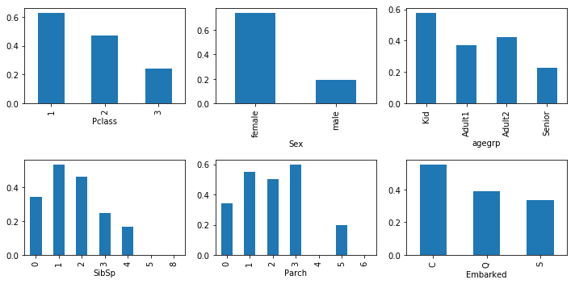

```python
fig, axes = plt.subplots(nrows=2, ncols=3, figsize = (10,5))
data1.groupby("Pclass").Survived.mean().plot(kind = "bar", ax = axes[0,0])
data1.groupby("Sex").Survived.mean().plot(kind = "bar", ax = axes[0,1])
data1.groupby("agegrp").Survived.mean().plot(kind = "bar", ax = axes[0,2])
data1.groupby("SibSp").Survived.mean().plot(kind = "bar", ax = axes[1,0])
data1.groupby("Parch").Survived.mean().plot(kind = "bar", ax = axes[1,1])
data1.groupby("Embarked").Survived.mean().plot(kind = "bar", ax = axes[1,2])



plt.tight_layout()
```

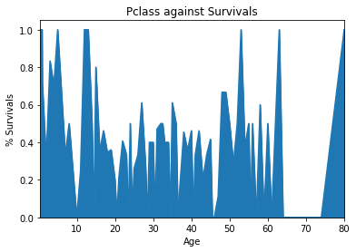

```python
data1.groupby("Age").Survived.mean().plot(kind = "area")
plt.xlabel("Age")
plt.ylabel("% Survivals")
plt.title("Pclass against Survivals")
```

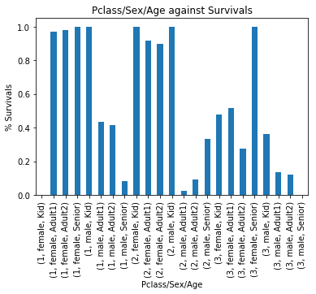

```python
data1.groupby(["Pclass","Sex","agegrp"]).Survived.mean().plot(kind = "bar")
plt.xlabel("Pclass/Sex/Age")
plt.ylabel("% Survivals")
plt.title("Pclass/Sex/Age against Survivals")
```

#### From the above graphs we conclude that Pclass, Sex, agegrp shows a strong pattern that the chances of survival. From the above graph we can see that womens and kids of any age of class 1 and 2 have nore than 80% chance of survival. There is no as such pattern we can uderstand from Sibsp and Parch. Also we can see Embarked has pattern. Now in the next step we will check if there is any specific reason why passengers who boarded Cherbourg, ship has a very high percentage of survival.

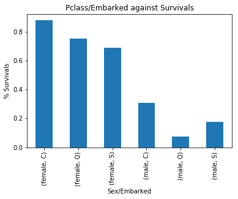

```python
data1.groupby(["Sex","Embarked"]).Survived.mean().plot(kind = "bar")
data1.groupby(["Embarked","Sex"]).Sex.count()
plt.xlabel("Sex/Embarked")
plt.ylabel("% Survivals")
plt.title("Pclass/Embarked against Survivals")
```

```python
data1.groupby(["Pclass", "agegrp"]).Pclass.count()
```

```
Pclass  agegrp
1       Kid         4
        Adult1     57
        Adult2    111
        Senior     14
2       Kid        17
        Adult1     79
        Adult2     74
        Senior      3
3       Kid        48
        Adult1    204
        Adult2     98
        Senior      5
Name: Pclass, dtype: int64
```

```python
data1.groupby("Sex").count()
```

| Sex | Survived | Pclass | agegrp | SibSp | Parch | Embarked | Age |
| --- | --- | --- | --- | --- | --- | --- | --- |
| female | 314 | 314 | 261 | 314 | 314 | 312 | 261 |
| male | 577 | 577 | 453 | 577 | 577 | 577 | 453 |

#### LIMITATIONS OF DATASET

WOULD LIKE TO KNOW MORE:

In my view the if the data on cabins and cabin location on ship and also data on crew can be found it can give us a more clear picutre. From the cabin and their location data we can analyse if there were any passengers who died because of the location of cabin for example people who were allocated with cabins which were situated in the last, had taken more come on the upper part of ship to take the boats.

Similarly if the data can be seggregated between passengers and crew, we can see the some more pattern in the data.